# Afternoon practical session

# GAMLSS modelling of aggregate UK electricity demand

- get the data and run a baseline GAM model

```r
library(mgcViz); library(gridExtra)
data("UKload")

form <- NetDemand~s(wM,k=20,bs='cr') + s(wM_s95,k=20,bs='cr') +
        s(Posan, k=30, bs = "cc") + Dow + s(Trend,k=4,bs='cr') +
        NetDemand.48 + Holy

fit0 <- gamV(form, data = UKload, aViz = list(nsim = 50))
```

- Look for patterns in the residuals conditional mean

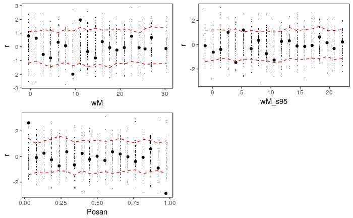

```r
pl <- list()
pl[[1]] <- ( check1D(fit0, "wM") + l_gridCheck1D(gridFun = mean, stand = "sc") )$ggObj      # OK
pl[[2]] <- ( check1D(fit0, "wM_s95") + l_gridCheck1D(gridFun = mean, stand = "sc") )$ggObj  # OK
pl[[3]] <- ( check1D(fit0, "Posan") + l_gridCheck1D(gridFun = mean, stand = "sc") )$ggObj   # Not OK
grid.arrange(grobs = pl, ncol = 2)
```

- `Posan` has large absolute residuals in January and December, indicating that the cyclic smoothing may not be correct.
- Drop cyclic smoothing and recheck.

```r
form <- NetDemand ~ s(wM,k=20,bs='cr') +
                    s(wM_s95,k=20,bs='cr') +
                    s(Posan,bs='cr',k=30) +  # <- Changed `cc` to `cr`
                    Dow + s(Trend,k=4) + NetDemand.48 + Holy

fit1 <- gamV(form, data = UKload, aViz = list(nsim = 50))

# Pattern in residuals mean is gone!
check1D(fit1, "Posan") + l_gridCheck1D(gridFun = mean)
```

[output not shown]

- Check the AIC

```r
AIC(fit0, fit1)
```

[output not shown]

- Look at variable plots

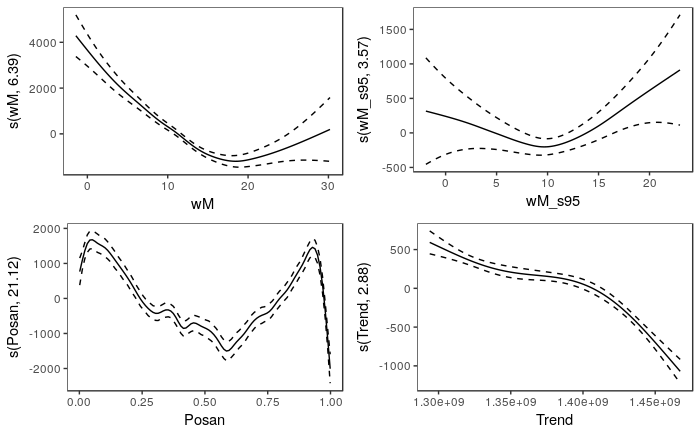

- Check the basis dimension basis

```r
tmp <- check(fit1)
```

```
Method: REML   Optimizer: outer newton
full convergence after 4 iterations.
Gradient range [-0.001888527,0.001255441]
(score 16671.19 & scale 968372).
Hessian positive definite, eigenvalue range [0.8398987,997.6139].
Model rank =  79 / 79

Basis dimension (k) checking results. Low p-value (k-index<1) may
indicate that k is too low, especially if edf is close to k'.

             k'   edf k-index p-value
s(wM)     19.00  6.39    0.99    0.34
s(wM_s95) 19.00  3.57    1.01    0.70
s(Posan)  29.00 21.12    0.95  <2e-16 ***
s(Trend)   3.00  2.88    1.10    1.00
---
Signif. codes:  0 ‘***’ 0.001 ‘**’ 0.01 ‘*’ 0.05 ‘.’ 0.1 ‘ ’ 1
```

- The `check` test indicates that k may be too low. Plotting the effect indicates that it drops sharply in December.
- Fit a model with adaptive smoothing.

```r
form <- NetDemand ~ s(wM,k=20,bs='cr') +
                    s(wM_s95,k=20,bs='cr') +
                    s(Posan,bs='ad',k=30) +  # <- Changed `cr` to `ad`
                    Dow + s(Trend,k=4) + NetDemand.48 + Holy
fit2 <- gamV(form, data = UKload, aViz = list(nsim = 50))

AIC( fit1, fit2 )
```

[output not shown]

- Plot the effect of `posan`

```r
plot(sm(fit2, 3), n = 400) + l_points() + l_fitLine() + l_ciLine() + theme_minimal()
```

[output not shown]

- Now the mean model is finalised we can look at the conditional variance of residuals. Using density plots is helpful as it avoids just looking at the mean distribution.

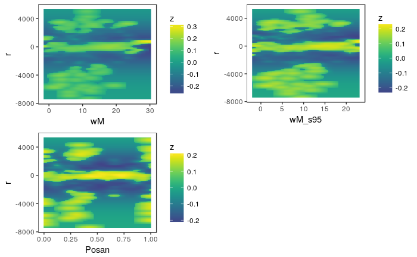

```r
pl <- list()
pl[[1]] <- ( check1D(fit2, "wM") + l_densCheck(n = c(100, 100), tol = -1) )$ggObj
pl[[2]] <- ( check1D(fit2, "wM_s95") + l_densCheck(n = c(100, 100), tol = -1) )$ggObj
pl[[3]] <- ( check1D(fit2, "Posan") + l_densCheck(n = c(100, 100), tol = -1) )$ggObj
grid.arrange(grobs = pl, ncol = 2)
```

- Some evidence of overdispersion check again using standardised plots

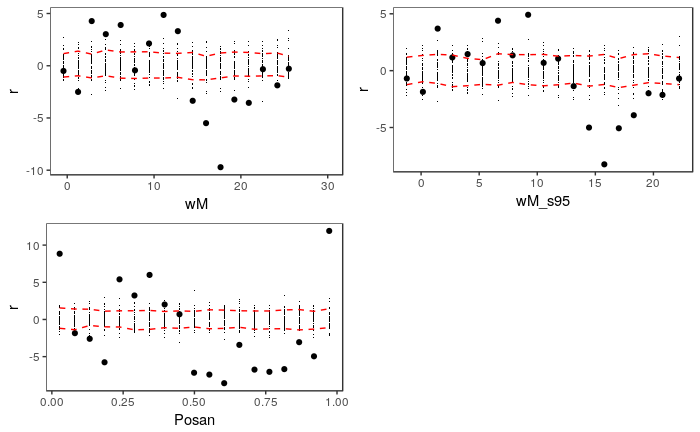

```r
pl <- list()
pl[[1]] <- ( check1D(fit2, "wM") + l_gridCheck1D(gridFun = sd, stand = "sc") )$ggObj
pl[[2]] <- ( check1D(fit2, "wM_s95") + l_gridCheck1D(gridFun = sd, stand = "sc") )$ggObj
pl[[3]] <- ( check1D(fit2, "Posan") + l_gridCheck1D(gridFun = sd, stand = "sc") )$ggObj
grid.arrange(grobs = pl, ncol = 2) # More evidence of heteroscedasticity
```

- All three variables having variable varinace. This could be addressed by fitting a GAMLSS model with variable scale.

```r
form <- list(NetDemand ~ s(wM,k=20,bs='cr') +
             s(wM_s95,k=20,bs='cr') +
             s(Posan,bs='ad',k=30) +
             Dow + s(Trend,k=4) + NetDemand.48 + Holy,
             ~ s(wM_s95,k=10,bs='cr') +
               s(Posan,bs='cr',k=20) +
               Dow)

fit3 <- gamV(form, family = gaulss, data = UKload, aViz = list(nsim = 50))

AIC(fit2, fit3)
```

[output not shown]

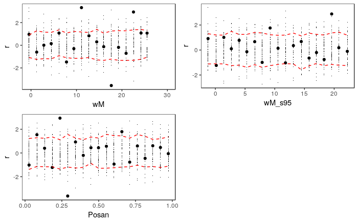

```r
pl <- list()
pl[[1]] <- ( check1D(fit3, "wM") + l_gridCheck1D(gridFun = sd, stand = "sc") )$ggObj
pl[[2]] <- ( check1D(fit3, "wM_s95") + l_gridCheck1D(gridFun = sd, stand = "sc") )$ggObj
pl[[3]] <- ( check1D(fit3, "Posan") + l_gridCheck1D(gridFun = sd, stand = "sc") )$ggObj
grid.arrange(grobs = pl, ncol = 2)
```

- Variance is reduced, relative to the location only Gaussian model. Now check skewness.

```r
qq(fit3)
```

[output not shown]

```r
library(e1071)
pl <- list()
pl[[1]] <- ( check1D(fit3, "wM_s95") + l_gridCheck1D(gridFun = skewness, stand = "sc") )$ggObj
pl[[2]] <- ( check1D(fit3, "Posan") + l_gridCheck1D(gridFun = skewness, stand = "sc") )$ggObj

grid.arrange(grobs = pl, ncol = 2)
```

[output not shown]

```r
library(mgcFam)
form <- list(NetDemand ~ s(wM,k=20,bs='cr') +
               s(wM_s95,k=20,bs='cr') +
               s(Posan,bs='ad',k=30) +
               s(Trend,k=4) + NetDemand.48 + Holy + Dow,
             ~ s(wM_s95,k=10,bs='cr') +
               s(Posan,bs='cr',k=20) +
               Dow,
             ~ s(Posan, k = 10, bs='cr') + Dow,
             ~ 1) # If convergence problems arise use
                  # ~ -1 + s(Holy, bs = "re", sp = 1e6) in place of ~ 1

fit4 <- gamV(form, family = shash, data = UKload,
             aViz = list(nsim = 50))

AIC(fit3, fit4) # Decreased again by a lot
```

[output not shown]

```r
pl <- list()
pl[[1]] <- ( check1D(fit4, "wM_s95") + l_gridCheck1D(gridFun = skewness, stand = "sc") )$ggObj
pl[[2]] <- ( check1D(fit4, "Posan") + l_gridCheck1D(gridFun = skewness, stand = "sc") )$ggObj

grid.arrange(grobs = pl, ncol = 2)
```

[output not shown]

[figure not shown]

[figure not shown]

# Body Mass Index (BMI) of Dutch Boys